# Data cleaning

David Pinho

2020-09-07

Note: some of this is a bit disjointed, but that’s how the sausage was made.

## What criteria to use when cleaning the data?

Most authors seem to have a set of objective rules, and then they manually see if there are any other observations worth excluding. For example, Liu et al. (2015) exclude all days with less than 60% of the standard daily time range. Bardorff-Nielsen et al. (2009) make a deeper analysis and cite other relevant articles.

### References

“Does anything beat 5-minute RV? A comparison of realized measures across multiple asset classes” by Liu, Patton, and Sheppard, 2015

“Realized kernels in practice: trades and quotes” by Bardorff-Nielsen, Hansen, Lunde and Shephard, 2009 (Journal of Econometrics)

## Libraries

```r
library(namespace)
library(data.table)
library(dplyr)
library(lubridate)
```

```r
library(ggplot2)
data.table::setDTthreads(threads=10)
```

## Global variables

```r
date_first <- as.Date("2000-01-01")
date_last <- as.Date("2010-12-31")
time_gmt_start <- as.ITime("08:00:00")
time_gmt_end <- as.ITime("16:30:00")
time_bst_start <- as.ITime("07:00:00")
time_bst_end <- as.ITime("15:30:00")

# Could not get knitr to set the path on the school's PC, so this had to do
path_raw_data <- 'C://Users//pg36869//Desktop//thesis-master-finance//data//ftse100//raw_data//'

# Source: https://www.dmo.gov.uk/media/15008/ukbankholidays.xls (saved as a csv file)
path_uk_holidays <- paste0(path_raw_data, 'ukbankholidays.csv')

# Source: https://greenwichmeantime.com/uk/time/british-summer-time/dates/ (copy-pasted everything to an excel file from 2000 to 2010, and saved as a csv file)
path_bst_time <- paste0(path_raw_data, 'bst.csv')

# Source: https://realized.oxford-man.ox.ac.uk/images/oxfordmanrealizedvolatilityindices-0.2-final.zip (extracted file, saved as csv)
path_rv_data <- paste0(path_raw_data, 'OxfordManRealizedVolatilityIndices.csv')

# Source: https://realized.oxford-man.ox.ac.uk/images/oxfordmanrealizedvolatilityindices.zip
# (extracted file, which was already a csv, converted eveything to a DD-MM-YYYY format,
# and saved it as oxfordmanrealizedvolatilityindices2.csv)
path_rv_data_alt <- paste0(path_raw_data, 'oxfordmanrealizedvolatilityindices2.csv')

# Source: Eikon Datastream; requested data from 04-01-2000 to 27-06-2019,
# named the columns "date" and "vftse" respectively, and saved as a csv
path_vftse <- paste0(path_raw_data, 'vftse.csv')
```

```r
# Loading the aggregate_data function.
source(file='C://Users//pg36869//Desktop//thesis-master-finance//R_scripts//1_generate_measures.R')
```

## Data variables

```r
data_ftse <- aggregate_data(path_data=path_raw_data,
                            regex_pattern='20[0-9][0-9].txt')
data_ftse[ , date := as.Date(date)]
data_ftse[ , time := data.table::as.ITime(time)]

# Returns
data_ftse[ , returns := (price / data.table::shift(price) - 1)]
data_ftse[ , time_change := as.numeric(time - data.table::shift(time))]

# Holidays
data_uk_holidays <- data.table::fread(path_uk_holidays, header=FALSE)
data_uk_holidays <- data_uk_holidays[3:length(V1), V1]
data_uk_holidays <- as.Date(data_uk_holidays,
                           format="%d-%b-%Y")
data_uk_holidays <- data_uk_holidays[(data_uk_holidays >= date_first)
                                     & (data_uk_holidays <= date_last)]

# GMT/BST
data_bst_time <- data.table::fread(path_bst_time, header=FALSE, stringsAsFactors=FALSE)
colnames(data_bst_time) <- c('start', 'end')
data_bst_time[ , start:=as.Date(start, format="%d-%m-%Y")]
data_bst_time[ , end:=as.Date(end, format="%d-%m-%Y")]

# Data from Sheppard and Shephard (OxfordMan)
data_paper <-  data.table::fread(path_rv_data, header=FALSE)
data_paper <- data_paper[ , c('V1', 'V21')]
data_paper <- data_paper[4:length(V1), ]
colnames(data_paper) <- c('date', 'rv')
data_paper[ , date := as.Date(date, format="%Y%m%d")]
data_paper <- data_paper %>% subset((date < as.Date("2011-01-01"))
                                     & (rv != ""))  # Some rows are empty

# Other data from OxfordMan with an updated methodology (to check for differences)
data_paper_alt <-  data.table::fread(path_rv_data, header=FALSE)
data_paper_alt <-  data_paper_alt[ , c('V1', 'V21')]
data_paper_alt <- data_paper_alt[4:length(V1), ]
colnames(data_paper_alt) <- c('date', 'rv')
data_paper_alt[ , date := as.Date(date, format="%Y%m%d")]
data_paper_alt <- data_paper_alt %>% subset((date < as.Date("2011-01-01"))
                                     & (rv != "")) # Some rows are empty

# VFTSE data
data_vftse <- data.table::fread(path_vftse, header=TRUE)
data_vftse[ , date := as.Date(date, format="%d-%m-%Y")]
data_vftse <- data_vftse[date <= as.Date("2011-01-01")]
data_vftse[ , vftse := as.numeric(sub(",", "..", vftse , fixed <- TRUE))]
```

## Flagging potential errors

```r
# Duplicated data (eliminates all but the last row in a group of duplicates)
duplicated <- duplicated(data_ftse[ , c("date", "time")],
                        fromLast=TRUE)
data_ftse <- data_ftse[ , is_duplicated := duplicated]

# Day changes and ordered days
data_ftse[ , is_day_change := ((date - data.table::shift(date)) > 0)]
data_ftse[ , is_unordered_day := ((date - data.table::shift(date)) < 0)]

# Ordered time
data_ftse[ , is_unordered_time := ((time_change < 0)
                                   & (is_day_change == FALSE))]

# Price is 0 or negative
data_ftse[ , is_wrong_price := (price <= 0)]

# Extreme returns
data_ftse[ , returns_per_time := abs(returns) / sqrt(abs(time_change))]

# Weekends
data_ftse[ , is_weekend := ((wday(date) == 7) | (wday(date) == 1))]

# BST time
dates_bst <- unlist(Map(`:`,  # maybe change this to "seq"
                       data_bst_time$start,
                       data_bst_time$end))
data_ftse[ , is_bst_time := date %in% dates_bst]

# Observations that are off-hours (8:00-16:30 GMT or 7:00-15:30 BST)
dt_time <- data_ftse$time
is_gmt <- !(data_ftse$is_bst_time)
is_bst <- (data_ftse$is_bst_time)
off_hours_gmt <- (((dt_time < time_gmt_start)
                    | (dt_time > time_gmt_end))
                 & is_gmt)
off_hours_bst <- (((dt_time < time_bst_start)
                    | (dt_time > time_bst_end))
                 & is_bst)
data_ftse[ , is_off_hours := (off_hours_bst | off_hours_gmt)]

# Holidays
data_ftse[ , is_holiday := (date %in% data_uk_holidays)]

# RV data
data_ftse[ , in_rv_dates := (date %in% data_paper$date)]
data_ftse[ , in_rv_dates_alt := (date %in% data_paper_alt$date)]

# vftse data
data_ftse[ , in_vftse_dates := (date %in% data_vftse$date)]
```

## Analyzing anomalies

### Variables without errors

```r
# All of these don't return anything
data_ftse[(is_holiday)]
```

| date | time | price | returns | time_change | is_duplicated | is_day_change | is_unordered_day | is_unordered_time | is_wrong_price | returns_per_time | is_weekend | is_bst_time | is_off_hours | is_holiday | in_rv_dates | in_rv_dates_alt | in_vftse_dates |
| --- | --- | --- | --- | --- | --- | --- | --- | --- | --- | --- | --- | --- | --- | --- | --- | --- | --- |

```r
data_ftse[(is_unordered_day)]
```

| date | time | price | returns | time_change | is_duplicated | is_day_change | is_unordered_day | is_unordered_time | is_wrong_price | returns_per_time | is_weekend | is_bst_time | is_off_hours | is_holiday | in_rv_dates | in_rv_dates_alt | in_vftse_dates |
| --- | --- | --- | --- | --- | --- | --- | --- | --- | --- | --- | --- | --- | --- | --- | --- | --- | --- |

```r
data_ftse[(is_wrong_price)]
```

| date | time | price | returns | time_change | is_duplicated | is_day_change | is_unordered_day | is_unordered_time | is_wrong_price | returns_per_time | is_weekend | is_bst_time | is_off_hours | is_holiday | in_rv_dates | in_rv_dates_alt | in_vftse_dates |
| --- | --- | --- | --- | --- | --- | --- | --- | --- | --- | --- | --- | --- | --- | --- | --- | --- | --- |

```r
data_ftse[(is_weekend)]
```

| date | time | price | returns | time_change | is_duplicated | is_day_change | is_unordered_day | is_unordered_time | is_wrong_price | returns_per_time | is_weekend | is_bst_time | is_off_hours | is_holiday | in_rv_dates | in_rv_dates_alt | in_vftse_dates |
| --- | --- | --- | --- | --- | --- | --- | --- | --- | --- | --- | --- | --- | --- | --- | --- | --- | --- |

### “Duplicated” data

```r
head(data_ftse[(is_duplicated)], 10)  # Remove head if you want to inspect the data; this is true from now on
```

| date | time | price | returns | time_change | is_duplicated | is_day_change | is_unordered_day | is_unordered_time | is_wrong_price | returns_per_time | is_weekend | is_bst_time | is_off_hours | is_holiday | in_rv_dates | in_rv_dates_alt | in_vftse_dates |
| --- | --- | --- | --- | --- | --- | --- | --- | --- | --- | --- | --- | --- | --- | --- | --- | --- | --- |
| 2000-01-19 | 08:15:29 | 6488.0 | -4.467793e-04 | 2 | TRUE | FALSE | FALSE | FALSE | FALSE | 3.159207e-04 | FALSE | FALSE | FALSE | FALSE | TRUE | TRUE | TRUE |
| 2000-01-24 | 08:11:35 | 6372.8 | 0.000000e+00 | 1 | TRUE | FALSE | FALSE | FALSE | FALSE | 0.000000e+00 | FALSE | FALSE | FALSE | FALSE | TRUE | TRUE | TRUE |
| 2000-01-24 | 08:11:39 | 6372.6 | 1.255532e-04 | 1 | TRUE | FALSE | FALSE | FALSE | FALSE | 1.255532e-04 | FALSE | FALSE | FALSE | FALSE | TRUE | TRUE | TRUE |
| 2000-02-11 | 16:13:56 | 6167.9 | -6.319064e-04 | 2 | TRUE | FALSE | FALSE | FALSE | FALSE | 4.468253e-04 | FALSE | FALSE | FALSE | FALSE | TRUE | TRUE | TRUE |
| 2000-02-11 | 16:13:59 | 6164.4 | 2.433919e-04 | 2 | TRUE | FALSE | FALSE | FALSE | FALSE | 1.721041e-04 | FALSE | FALSE | FALSE | FALSE | TRUE | TRUE | TRUE |
| 2000-02-14 | 12:36:37 | 6114.3 | 6.546323e-04 | 48 | TRUE | FALSE | FALSE | FALSE | FALSE | 9.448804e-05 | FALSE | FALSE | FALSE | FALSE | TRUE | TRUE | TRUE |
| 2000-09-12 | 09:37:22 | 6559.6 | 0.000000e+00 | 7 | TRUE | FALSE | FALSE | FALSE | FALSE | 0.000000e+00 | FALSE | TRUE | FALSE | FALSE | TRUE | TRUE | TRUE |
| 2000-10-23 | 12:56:26 | 6279.4 | -2.388193e-04 | 43 | TRUE | FALSE | FALSE | FALSE | FALSE | 3.641960e-05 | FALSE | TRUE | FALSE | FALSE | TRUE | TRUE | TRUE |
| 2000-11-13 | 09:33:05 | 6357.4 | 3.146039e-05 | 273 | TRUE | FALSE | FALSE | FALSE | FALSE | 1.904070e-06 | FALSE | FALSE | FALSE | FALSE | TRUE | TRUE | TRUE |
| 2000-11-13 | 15:17:18 | 6309.8 | 6.026007e-04 | 270 | TRUE | FALSE | FALSE | FALSE | FALSE | 3.667311e-05 | FALSE | FALSE | FALSE | FALSE | TRUE | TRUE | TRUE |

These are returns that happened in the exact same day and time. Note that “is_duplicated” doesn’t flag the last observation in a group of duplicated observations.

These won’t have any influence on the analysis because to create n minute returns, you only need the last observation. But I’ll them because so that I do not use as much RAM.

### Are times correctly ordered?

```r
head(data_ftse[order(time_change) & (is_unordered_time)])
```

| date | time | price | returns | time_change | is_duplicated | is_day_change | is_unordered_day | is_unordered_time | is_wrong_price | returns_per_time | is_weekend | is_bst_time | is_off_hours | is_holiday | in_rv_dates | in_rv_dates_alt | in_vftse_dates |
| --- | --- | --- | --- | --- | --- | --- | --- | --- | --- | --- | --- | --- | --- | --- | --- | --- | --- |
| 2009-11-30 | 08:00:54 | 5256.98 | 7.608989e-06 | -1 | FALSE | FALSE | FALSE | TRUE | FALSE | 7.608989e-06 | FALSE | FALSE | FALSE | FALSE | TRUE | TRUE | TRUE |
| 2009-11-30 | 08:00:57 | 5261.92 | 5.701373e-06 | -1 | FALSE | FALSE | FALSE | TRUE | FALSE | 5.701373e-06 | FALSE | FALSE | FALSE | FALSE | TRUE | TRUE | TRUE |
| 2009-11-30 | 08:01:23 | 5255.43 | -1.331938e-05 | -1 | FALSE | FALSE | FALSE | TRUE | FALSE | 1.331938e-05 | FALSE | FALSE | FALSE | FALSE | TRUE | TRUE | TRUE |
| 2009-11-30 | 08:01:24 | 5255.43 | -6.469081e-05 | -1 | FALSE | FALSE | FALSE | TRUE | FALSE | 6.469081e-05 | FALSE | FALSE | FALSE | FALSE | TRUE | TRUE | TRUE |
| 2009-11-30 | 08:02:41 | 5255.16 | 1.902895e-06 | -1 | FALSE | FALSE | FALSE | TRUE | FALSE | 1.902895e-06 | FALSE | FALSE | FALSE | FALSE | TRUE | TRUE | TRUE |
| 2009-11-30 | 08:02:52 | 5255.28 | 3.234947e-05 | -1 | FALSE | FALSE | FALSE | TRUE | FALSE | 3.234947e-05 | FALSE | FALSE | FALSE | FALSE | TRUE | TRUE | TRUE |

**Deleted observations**: 78 from 2009-11-30 where `in_unordered_time == TRUE`. It’s most likely an error because: - All of these returns happened inside trading hours; - They generally only decrease one/two seconds relative to their previous observation; - They’re extremely small returns (median ‘returns_per_time’ is almost 2x bigger than the median of these returns); - There was no news on this day.

### Are there observations outside trading hours?

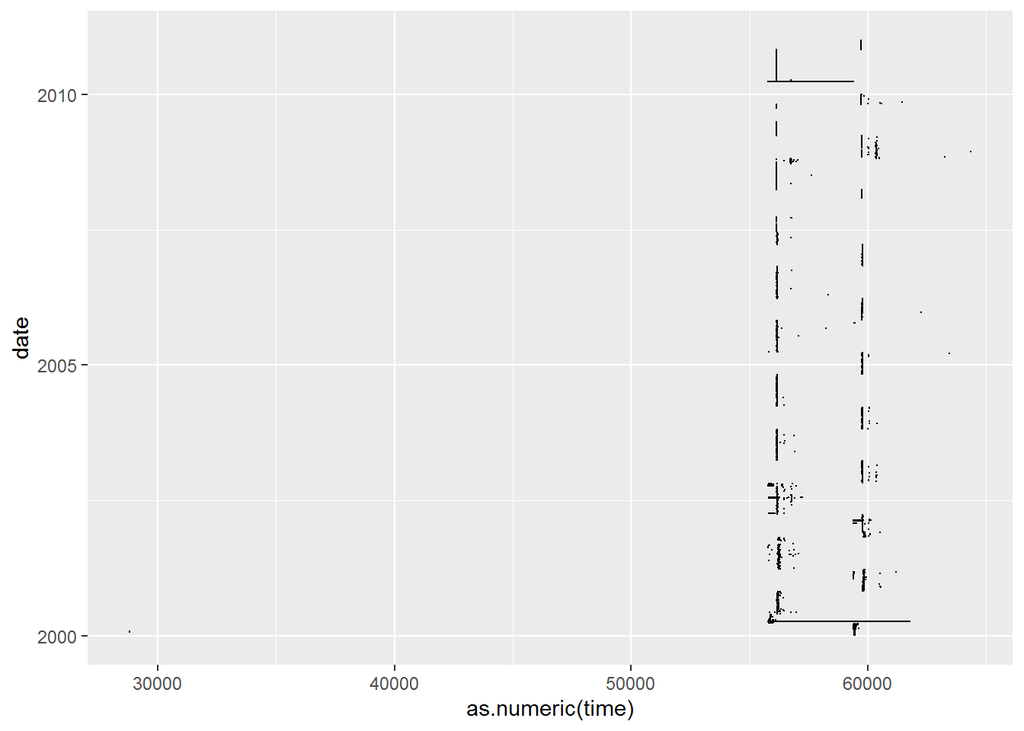

```r
data_ftse[(is_off_hours)] %>%
  ggplot() +
  geom_point(aes(y=date, x=as.numeric(time)),
             shape= 19, size=0.1)
```

```r
data_ftse[(is_off_hours)
           & (as.numeric(time) < 55800)]$time  # 55800 is 15:30
```

```
## [1] "07:59:59" "07:59:59" "07:59:59" "07:59:59" "07:59:59"
```

```r
data_ftse[(is_off_hours & order(time))] %>%
  count(date, sort=TRUE) %>%
  head
```

| date | n |
| --- | --- |
| 2010-03-30 | 8132 |
| 2010-03-31 | 7540 |
| 2010-03-29 | 6836 |
| 2000-04-05 | 399 |
| 2002-07-19 | 32 |
| 2002-07-23 | 31 |

```r
anomalous_dates <- data_ftse[(date == as.Date('2010-03-29'))
                             | (date == as.Date('2010-03-30'))
                             | (date == as.Date('2010-03-31'))
                             | (date == as.Date('2000-04-05'))]
anomalous_dates[order(date), tail(.SD, 5L), by=date]
```

| date | time | price | returns | time_change | is_duplicated | is_day_change | is_unordered_day | is_unordered_time | is_wrong_price | returns_per_time | is_weekend | is_bst_time | is_off_hours | is_holiday | in_rv_dates | in_rv_dates_alt | in_vftse_dates |
| --- | --- | --- | --- | --- | --- | --- | --- | --- | --- | --- | --- | --- | --- | --- | --- | --- | --- |
| 2000-04-05 | 17:08:45 | 6352.30 | 2.361907e-04 | 14 | FALSE | FALSE | FALSE | FALSE | FALSE | 6.312462e-05 | FALSE | TRUE | TRUE | FALSE | TRUE | TRUE | TRUE |
| 2000-04-05 | 17:09:00 | 6355.50 | 5.037545e-04 | 15 | FALSE | FALSE | FALSE | FALSE | FALSE | 1.300689e-04 | FALSE | TRUE | TRUE | FALSE | TRUE | TRUE | TRUE |
| 2000-04-05 | 17:09:15 | 6356.40 | 1.416096e-04 | 15 | FALSE | FALSE | FALSE | FALSE | FALSE | 3.656345e-05 | FALSE | TRUE | TRUE | FALSE | TRUE | TRUE | TRUE |
| 2000-04-05 | 17:09:31 | 6357.60 | 1.887861e-04 | 16 | FALSE | FALSE | FALSE | FALSE | FALSE | 4.719653e-05 | FALSE | TRUE | TRUE | FALSE | TRUE | TRUE | TRUE |
| 2000-04-05 | 17:09:45 | 6357.50 | -1.572921e-05 | 14 | FALSE | FALSE | FALSE | FALSE | FALSE | 4.203807e-06 | FALSE | TRUE | TRUE | FALSE | TRUE | TRUE | TRUE |
| 2010-03-29 | 16:29:43 | 5713.11 | -1.750329e-05 | 0 | FALSE | FALSE | FALSE | FALSE | FALSE | Inf | FALSE | TRUE | TRUE | FALSE | TRUE | TRUE | TRUE |
| 2010-03-29 | 16:29:44 | 5713.16 | 8.751801e-06 | 1 | TRUE | FALSE | FALSE | FALSE | FALSE | 8.751801e-06 | FALSE | TRUE | TRUE | FALSE | TRUE | TRUE | TRUE |
| 2010-03-29 | 16:29:44 | 5713.15 | -1.750345e-06 | 0 | TRUE | FALSE | FALSE | FALSE | FALSE | Inf | FALSE | TRUE | TRUE | FALSE | TRUE | TRUE | TRUE |
| 2010-03-29 | 16:29:44 | 5713.09 | -1.050209e-05 | 0 | TRUE | FALSE | FALSE | FALSE | FALSE | Inf | FALSE | TRUE | TRUE | FALSE | TRUE | TRUE | TRUE |
| 2010-03-29 | 16:29:44 | 5713.01 | -1.400293e-05 | 0 | FALSE | FALSE | FALSE | FALSE | FALSE | Inf | FALSE | TRUE | TRUE | FALSE | TRUE | TRUE | TRUE |

[output cut: 10 more lines]

```r
anomalous_dates[order(date), head(.SD, 5L), by=date]
```

| date | time | price | returns | time_change | is_duplicated | is_day_change | is_unordered_day | is_unordered_time | is_wrong_price | returns_per_time | is_weekend | is_bst_time | is_off_hours | is_holiday | in_rv_dates | in_rv_dates_alt | in_vftse_dates |
| --- | --- | --- | --- | --- | --- | --- | --- | --- | --- | --- | --- | --- | --- | --- | --- | --- | --- |
| 2000-04-05 | 14:32:46 | 6427.00 | 0.000000e+00 | -3628 | FALSE | TRUE | FALSE | FALSE | FALSE | 0.000000e+00 | FALSE | TRUE | FALSE | FALSE | TRUE | TRUE | TRUE |
| 2000-04-05 | 14:33:00 | 6427.00 | 0.000000e+00 | 14 | FALSE | FALSE | FALSE | FALSE | FALSE | 0.000000e+00 | FALSE | TRUE | FALSE | FALSE | TRUE | TRUE | TRUE |
| 2000-04-05 | 14:33:15 | 6427.00 | 0.000000e+00 | 15 | FALSE | FALSE | FALSE | FALSE | FALSE | 0.000000e+00 | FALSE | TRUE | FALSE | FALSE | TRUE | TRUE | TRUE |
| 2000-04-05 | 14:33:30 | 6427.00 | 0.000000e+00 | 15 | FALSE | FALSE | FALSE | FALSE | FALSE | 0.000000e+00 | FALSE | TRUE | FALSE | FALSE | TRUE | TRUE | TRUE |
| 2000-04-05 | 14:33:45 | 6427.00 | 0.000000e+00 | 15 | FALSE | FALSE | FALSE | FALSE | FALSE | 0.000000e+00 | FALSE | TRUE | FALSE | FALSE | TRUE | TRUE | TRUE |
| 2010-03-29 | 08:00:00 | 5703.02 | 8.757413e-04 | -30584 | FALSE | TRUE | FALSE | FALSE | FALSE | 5.007589e-06 | FALSE | TRUE | FALSE | FALSE | TRUE | TRUE | TRUE |
| 2010-03-29 | 08:00:02 | 5703.10 | 1.402766e-05 | 2 | TRUE | FALSE | FALSE | FALSE | FALSE | 9.919050e-06 | FALSE | TRUE | FALSE | FALSE | TRUE | TRUE | TRUE |
| 2010-03-29 | 08:00:02 | 5703.25 | 2.630149e-05 | 0 | TRUE | FALSE | FALSE | FALSE | FALSE | Inf | FALSE | TRUE | FALSE | FALSE | TRUE | TRUE | TRUE |
| 2010-03-29 | 08:00:02 | 5704.18 | 1.630649e-04 | 0 | FALSE | FALSE | FALSE | FALSE | FALSE | Inf | FALSE | TRUE | FALSE | FALSE | TRUE | TRUE | TRUE |
| 2010-03-29 | 08:00:03 | 5704.25 | 1.227170e-05 | 1 | TRUE | FALSE | FALSE | FALSE | FALSE | 1.227170e-05 | FALSE | TRUE | FALSE | FALSE | TRUE | TRUE | TRUE |

[output cut: 10 more lines]

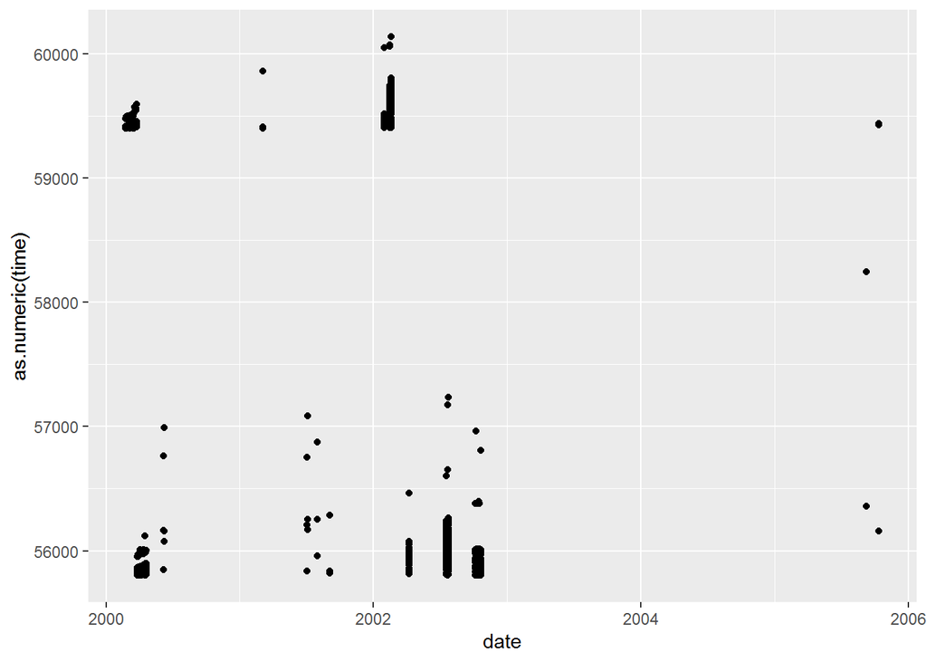

```r
# Days with an intermediate amount of off-hours time
list_bad_days <- data_ftse[(is_off_hours & order(time))] %>%
                    count(date, sort=TRUE)
interm_day <- setDT(list_bad_days)[(n<399) & (n>2)]$date
data_ftse[(date %in% interm_day) & (is_off_hours == TRUE)] %>%
  ggplot() +
  geom_point(aes(x=date, y=as.numeric(time)))
```

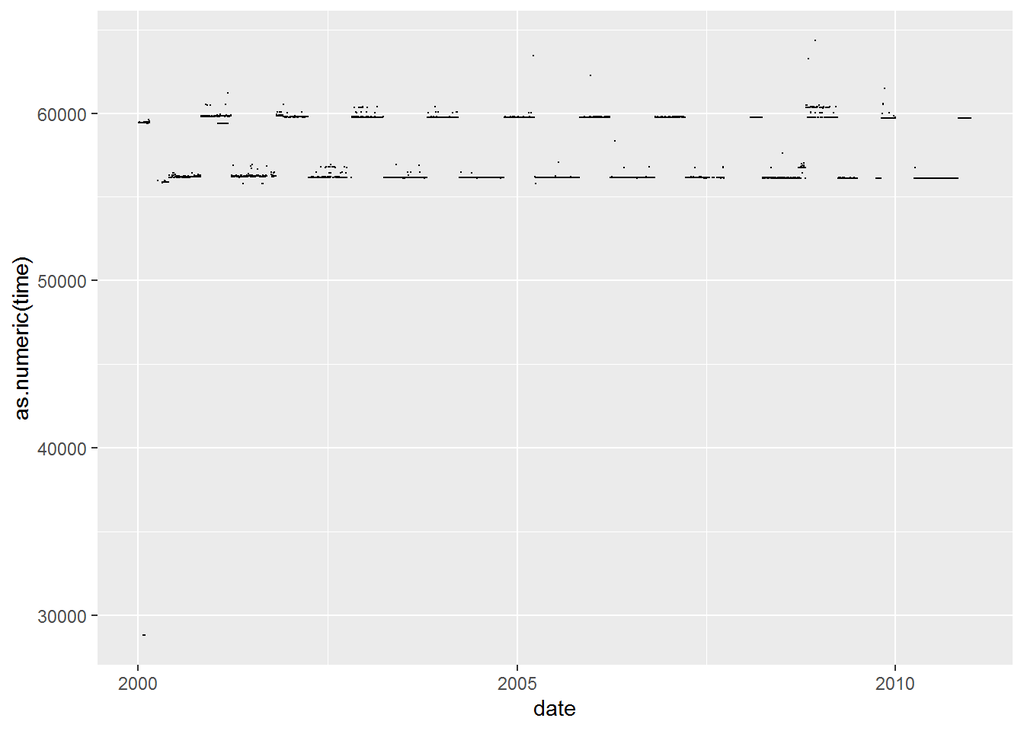

```r
small_days <- setDT(list_bad_days)[(n < 3)]$date
data_ftse[(date %in% small_days) & (is_off_hours)] %>%
  ggplot() +
  geom_point(aes(x=date, y=as.numeric(time)), shape=19, size=0.1)
```

```r
# These return nothing
data_ftse[(date %in% small_days) & (is_off_hours)
           & (is_bst) & (time < as.ITime("15:30"))]
```

| date | time | price | returns | time_change | is_duplicated | is_day_change | is_unordered_day | is_unordered_time | is_wrong_price | returns_per_time | is_weekend | is_bst_time | is_off_hours | is_holiday | in_rv_dates | in_rv_dates_alt | in_vftse_dates |
| --- | --- | --- | --- | --- | --- | --- | --- | --- | --- | --- | --- | --- | --- | --- | --- | --- | --- |

```r
data_ftse[(date %in% small_days) & (is_off_hours)
           & (is_bst) & (time < as.ITime("07:00"))]
```

| date | time | price | returns | time_change | is_duplicated | is_day_change | is_unordered_day | is_unordered_time | is_wrong_price | returns_per_time | is_weekend | is_bst_time | is_off_hours | is_holiday | in_rv_dates | in_rv_dates_alt | in_vftse_dates |
| --- | --- | --- | --- | --- | --- | --- | --- | --- | --- | --- | --- | --- | --- | --- | --- | --- | --- |

```r
data_ftse[(date %in% small_days) & (is_off_hours)
           & (!is_bst) & (time < as.ITime("16:30"))] # only returns periods before 08:00:00
```

| date | time | price | returns | time_change | is_duplicated | is_day_change | is_unordered_day | is_unordered_time | is_wrong_price | returns_per_time | is_weekend | is_bst_time | is_off_hours | is_holiday | in_rv_dates | in_rv_dates_alt | in_vftse_dates |
| --- | --- | --- | --- | --- | --- | --- | --- | --- | --- | --- | --- | --- | --- | --- | --- | --- | --- |
| 2000-01-25 | 07:59:59 | 6379.8 | 0 | -30652 | FALSE | TRUE | FALSE | FALSE | FALSE | 0 | FALSE | FALSE | TRUE | FALSE | TRUE | TRUE | TRUE |
| 2000-01-26 | 07:59:59 | 6274.1 | 0 | -30643 | FALSE | TRUE | FALSE | FALSE | FALSE | 0 | FALSE | FALSE | TRUE | FALSE | TRUE | TRUE | TRUE |
| 2000-01-27 | 07:59:59 | 6375.6 | 0 | -30649 | FALSE | TRUE | FALSE | FALSE | FALSE | 0 | FALSE | FALSE | TRUE | FALSE | TRUE | TRUE | TRUE |
| 2000-01-28 | 07:59:59 | 6441.0 | 0 | -30655 | FALSE | TRUE | FALSE | FALSE | FALSE | 0 | FALSE | FALSE | TRUE | FALSE | TRUE | TRUE | TRUE |
| 2000-01-31 | 07:59:59 | 6375.6 | 0 | -30669 | FALSE | TRUE | FALSE | FALSE | FALSE | 0 | FALSE | FALSE | TRUE | FALSE | TRUE | TRUE | TRUE |

```r
data_ftse[(date %in% small_days) & (is_off_hours)
           & (!is_bst) & (time < as.ITime("08:00"))] # only returns periods before 08:00:00
```

| date | time | price | returns | time_change | is_duplicated | is_day_change | is_unordered_day | is_unordered_time | is_wrong_price | returns_per_time | is_weekend | is_bst_time | is_off_hours | is_holiday | in_rv_dates | in_rv_dates_alt | in_vftse_dates |
| --- | --- | --- | --- | --- | --- | --- | --- | --- | --- | --- | --- | --- | --- | --- | --- | --- | --- |
| 2000-01-25 | 07:59:59 | 6379.8 | 0 | -30652 | FALSE | TRUE | FALSE | FALSE | FALSE | 0 | FALSE | FALSE | TRUE | FALSE | TRUE | TRUE | TRUE |
| 2000-01-26 | 07:59:59 | 6274.1 | 0 | -30643 | FALSE | TRUE | FALSE | FALSE | FALSE | 0 | FALSE | FALSE | TRUE | FALSE | TRUE | TRUE | TRUE |
| 2000-01-27 | 07:59:59 | 6375.6 | 0 | -30649 | FALSE | TRUE | FALSE | FALSE | FALSE | 0 | FALSE | FALSE | TRUE | FALSE | TRUE | TRUE | TRUE |
| 2000-01-28 | 07:59:59 | 6441.0 | 0 | -30655 | FALSE | TRUE | FALSE | FALSE | FALSE | 0 | FALSE | FALSE | TRUE | FALSE | TRUE | TRUE | TRUE |
| 2000-01-31 | 07:59:59 | 6375.6 | 0 | -30669 | FALSE | TRUE | FALSE | FALSE | FALSE | 0 | FALSE | FALSE | TRUE | FALSE | TRUE | TRUE | TRUE |

```r
data_ftse[(date %in% small_days) & (is_off_hours)]$returns_per_time %>%
    na.omit() %>%
    median()
```

```
## [1] 3.433593e-05
```

```r
data_ftse[(date %in% small_days) & (!is_off_hours)]$returns_per_time %>%
    na.omit() %>%
    median()
```

```
## [1] 4.007433e-05
```

### Time changes that are too big

```r
# Every time change is positive or equal than 0 (see explanation)
data_ftse[(!is_day_change) & (!is_unordered_time)
           & (!is_duplicated) & (!is_off_hours)][order(time_change)] %>%
  head
```

| date | time | price | returns | time_change | is_duplicated | is_day_change | is_unordered_day | is_unordered_time | is_wrong_price | returns_per_time | is_weekend | is_bst_time | is_off_hours | is_holiday | in_rv_dates | in_rv_dates_alt | in_vftse_dates |
| --- | --- | --- | --- | --- | --- | --- | --- | --- | --- | --- | --- | --- | --- | --- | --- | --- | --- |
| 2000-01-19 | 08:15:29 | 6486.3 | -2.620222e-04 | 0 | FALSE | FALSE | FALSE | FALSE | FALSE | Inf | FALSE | FALSE | FALSE | FALSE | TRUE | TRUE | TRUE |
| 2000-01-24 | 08:11:35 | 6372.4 | -6.276676e-05 | 0 | FALSE | FALSE | FALSE | FALSE | FALSE | Inf | FALSE | FALSE | FALSE | FALSE | TRUE | TRUE | TRUE |
| 2000-01-24 | 08:11:39 | 6373.8 | 1.883062e-04 | 0 | FALSE | FALSE | FALSE | FALSE | FALSE | Inf | FALSE | FALSE | FALSE | FALSE | TRUE | TRUE | TRUE |
| 2000-02-11 | 16:13:56 | 6166.6 | -2.107687e-04 | 0 | FALSE | FALSE | FALSE | FALSE | FALSE | Inf | FALSE | FALSE | FALSE | FALSE | TRUE | TRUE | TRUE |
| 2000-02-11 | 16:13:59 | 6163.8 | -9.733307e-05 | 0 | FALSE | FALSE | FALSE | FALSE | FALSE | Inf | FALSE | FALSE | FALSE | FALSE | TRUE | TRUE | TRUE |
| 2000-02-14 | 12:36:37 | 6114.2 | -1.635510e-05 | 0 | FALSE | FALSE | FALSE | FALSE | FALSE | Inf | FALSE | FALSE | FALSE | FALSE | TRUE | TRUE | TRUE |

```r
# Most of these observations don't look reasonable
big_time_change <- data_ftse[((!is_day_change) & (!is_unordered_time)
                              & (!is_duplicated) & (!is_off_hours)
                              & (time_change > 60) & (returns != 0))][order(-time_change)]
head(big_time_change)
```

| date | time | price | returns | time_change | is_duplicated | is_day_change | is_unordered_day | is_unordered_time | is_wrong_price | returns_per_time | is_weekend | is_bst_time | is_off_hours | is_holiday | in_rv_dates | in_rv_dates_alt | in_vftse_dates |
| --- | --- | --- | --- | --- | --- | --- | --- | --- | --- | --- | --- | --- | --- | --- | --- | --- | --- |
| 2003-04-14 | 15:29:03 | 3852.7 | 0.0066102315 | 19771 | FALSE | FALSE | FALSE | FALSE | FALSE | 4.701131e-05 | FALSE | TRUE | FALSE | FALSE | TRUE | TRUE | TRUE |
| 2000-04-03 | 11:36:13 | 6485.1 | -0.0084248188 | 16396 | FALSE | FALSE | FALSE | FALSE | FALSE | 6.579481e-05 | FALSE | TRUE | FALSE | FALSE | TRUE | TRUE | TRUE |
| 2007-08-09 | 14:05:49 | 6263.4 | -0.0054622249 | 9646 | FALSE | FALSE | FALSE | FALSE | FALSE | 5.561551e-05 | FALSE | TRUE | FALSE | FALSE | TRUE | TRUE | TRUE |
| 2004-01-27 | 14:38:02 | 4466.2 | -0.0017657182 | 7800 | FALSE | FALSE | FALSE | FALSE | FALSE | 1.999282e-05 | FALSE | FALSE | FALSE | FALSE | TRUE | TRUE | TRUE |
| 2005-01-31 | 14:43:53 | 4861.4 | -0.0003906812 | 6322 | FALSE | FALSE | FALSE | FALSE | FALSE | 4.913549e-06 | FALSE | FALSE | FALSE | FALSE | TRUE | TRUE | TRUE |
| 2005-06-13 | 11:11:17 | 5034.7 | -0.0012299391 | 5071 | FALSE | FALSE | FALSE | FALSE | FALSE | 1.727177e-05 | FALSE | TRUE | FALSE | FALSE | TRUE | TRUE | TRUE |

```r
# Closer look at each day with big anomalies (times are close to the big jumps in time)
data_ftse[(date == as.Date("2003-04-14")) & (time > as.ITime("09:55:00"))]
```

| date | time | price | returns | time_change | is_duplicated | is_day_change | is_unordered_day | is_unordered_time | is_wrong_price | returns_per_time | is_weekend | is_bst_time | is_off_hours | is_holiday | in_rv_dates | in_rv_dates_alt | in_vftse_dates |
| --- | --- | --- | --- | --- | --- | --- | --- | --- | --- | --- | --- | --- | --- | --- | --- | --- | --- |
| 2003-04-14 | 09:55:17 | 3828.2 | 1.567562e-04 | 30 | FALSE | FALSE | FALSE | FALSE | FALSE | 2.861963e-05 | FALSE | TRUE | FALSE | FALSE | TRUE | TRUE | TRUE |
| 2003-04-14 | 09:55:35 | 3828.3 | 2.612194e-05 | 18 | FALSE | FALSE | FALSE | FALSE | FALSE | 6.157000e-06 | FALSE | TRUE | FALSE | FALSE | TRUE | TRUE | TRUE |
| 2003-04-14 | 09:55:47 | 3828.7 | 1.044850e-04 | 12 | FALSE | FALSE | FALSE | FALSE | FALSE | 3.016223e-05 | FALSE | TRUE | FALSE | FALSE | TRUE | TRUE | TRUE |
| 2003-04-14 | 09:56:06 | 3828.9 | 5.223705e-05 | 19 | FALSE | FALSE | FALSE | FALSE | FALSE | 1.198400e-05 | FALSE | TRUE | FALSE | FALSE | TRUE | TRUE | TRUE |
| 2003-04-14 | 09:56:17 | 3829.0 | 2.611716e-05 | 11 | FALSE | FALSE | FALSE | FALSE | FALSE | 7.874621e-06 | FALSE | TRUE | FALSE | FALSE | TRUE | TRUE | TRUE |
| 2003-04-14 | 09:56:32 | 3828.2 | -2.089318e-04 | 15 | FALSE | FALSE | FALSE | FALSE | FALSE | 5.394597e-05 | FALSE | TRUE | FALSE | FALSE | TRUE | TRUE | TRUE |
| 2003-04-14 | 09:56:47 | 3829.0 | 2.089755e-04 | 15 | FALSE | FALSE | FALSE | FALSE | FALSE | 5.395724e-05 | FALSE | TRUE | FALSE | FALSE | TRUE | TRUE | TRUE |
| 2003-04-14 | 09:57:03 | 3827.7 | -3.395142e-04 | 16 | FALSE | FALSE | FALSE | FALSE | FALSE | 8.487856e-05 | FALSE | TRUE | FALSE | FALSE | TRUE | TRUE | TRUE |
| 2003-04-14 | 09:57:18 | 3827.0 | -1.828774e-04 | 15 | FALSE | FALSE | FALSE | FALSE | FALSE | 4.721875e-05 | FALSE | TRUE | FALSE | FALSE | TRUE | TRUE | TRUE |
| 2003-04-14 | 09:57:32 | 3827.1 | 2.613013e-05 | 14 | FALSE | FALSE | FALSE | FALSE | FALSE | 6.983570e-06 | FALSE | TRUE | FALSE | FALSE | TRUE | TRUE | TRUE |

[output cut: 9 more lines]

```r
head(data_ftse[(date == as.Date("2000-04-03"))])
```

| date | time | price | returns | time_change | is_duplicated | is_day_change | is_unordered_day | is_unordered_time | is_wrong_price | returns_per_time | is_weekend | is_bst_time | is_off_hours | is_holiday | in_rv_dates | in_rv_dates_alt | in_vftse_dates |
| --- | --- | --- | --- | --- | --- | --- | --- | --- | --- | --- | --- | --- | --- | --- | --- | --- | --- |
| 2000-04-03 | 07:01:30 | 6540.2 | 0 | -30683 | FALSE | TRUE | FALSE | FALSE | FALSE | 0 | FALSE | TRUE | FALSE | FALSE | TRUE | TRUE | TRUE |
| 2000-04-03 | 07:01:42 | 6540.2 | 0 | 12 | FALSE | FALSE | FALSE | FALSE | FALSE | 0 | FALSE | TRUE | FALSE | FALSE | TRUE | TRUE | TRUE |
| 2000-04-03 | 07:01:56 | 6540.2 | 0 | 14 | FALSE | FALSE | FALSE | FALSE | FALSE | 0 | FALSE | TRUE | FALSE | FALSE | TRUE | TRUE | TRUE |
| 2000-04-03 | 07:02:11 | 6540.2 | 0 | 15 | FALSE | FALSE | FALSE | FALSE | FALSE | 0 | FALSE | TRUE | FALSE | FALSE | TRUE | TRUE | TRUE |
| 2000-04-03 | 07:02:27 | 6540.2 | 0 | 16 | FALSE | FALSE | FALSE | FALSE | FALSE | 0 | FALSE | TRUE | FALSE | FALSE | TRUE | TRUE | TRUE |
| 2000-04-03 | 07:02:42 | 6540.2 | 0 | 15 | FALSE | FALSE | FALSE | FALSE | FALSE | 0 | FALSE | TRUE | FALSE | FALSE | TRUE | TRUE | TRUE |

```r
head(data_ftse[(date == as.Date("2007-08-09") & (time > as.ITime("11:00:00")))])
```

| date | time | price | returns | time_change | is_duplicated | is_day_change | is_unordered_day | is_unordered_time | is_wrong_price | returns_per_time | is_weekend | is_bst_time | is_off_hours | is_holiday | in_rv_dates | in_rv_dates_alt | in_vftse_dates |
| --- | --- | --- | --- | --- | --- | --- | --- | --- | --- | --- | --- | --- | --- | --- | --- | --- | --- |
| 2007-08-09 | 11:00:18 | 6291.1 | 1.589572e-05 | 30 | FALSE | FALSE | FALSE | FALSE | FALSE | 2.902149e-06 | FALSE | TRUE | FALSE | FALSE | TRUE | TRUE | TRUE |
| 2007-08-09 | 11:00:34 | 6289.8 | -2.066411e-04 | 16 | FALSE | FALSE | FALSE | FALSE | FALSE | 5.166028e-05 | FALSE | TRUE | FALSE | FALSE | TRUE | TRUE | TRUE |
| 2007-08-09 | 11:01:04 | 6291.9 | 3.338739e-04 | 30 | FALSE | FALSE | FALSE | FALSE | FALSE | 6.095675e-05 | FALSE | TRUE | FALSE | FALSE | TRUE | TRUE | TRUE |
| 2007-08-09 | 11:01:18 | 6292.1 | 3.178690e-05 | 14 | FALSE | FALSE | FALSE | FALSE | FALSE | 8.495407e-06 | FALSE | TRUE | FALSE | FALSE | TRUE | TRUE | TRUE |
| 2007-08-09 | 11:01:33 | 6290.3 | -2.860730e-04 | 15 | FALSE | FALSE | FALSE | FALSE | FALSE | 7.386373e-05 | FALSE | TRUE | FALSE | FALSE | TRUE | TRUE | TRUE |
| 2007-08-09 | 11:01:48 | 6290.4 | 1.589749e-05 | 15 | FALSE | FALSE | FALSE | FALSE | FALSE | 4.104715e-06 | FALSE | TRUE | FALSE | FALSE | TRUE | TRUE | TRUE |

```r
head(data_ftse[(date == as.Date("2004-01-27") & (time > as.ITime("12:28:00")))])
```

| date | time | price | returns | time_change | is_duplicated | is_day_change | is_unordered_day | is_unordered_time | is_wrong_price | returns_per_time | is_weekend | is_bst_time | is_off_hours | is_holiday | in_rv_dates | in_rv_dates_alt | in_vftse_dates |
| --- | --- | --- | --- | --- | --- | --- | --- | --- | --- | --- | --- | --- | --- | --- | --- | --- | --- |
| 2004-01-27 | 12:28:02 | 4474.1 | 2.235136e-05 | 15 | FALSE | FALSE | FALSE | FALSE | FALSE | 5.771097e-06 | FALSE | FALSE | FALSE | FALSE | TRUE | TRUE | TRUE |
| 2004-01-27 | 14:38:02 | 4466.2 | -1.765718e-03 | 7800 | FALSE | FALSE | FALSE | FALSE | FALSE | 1.999282e-05 | FALSE | FALSE | FALSE | FALSE | TRUE | TRUE | TRUE |
| 2004-01-27 | 14:38:18 | 4467.2 | 2.239040e-04 | 16 | FALSE | FALSE | FALSE | FALSE | FALSE | 5.597600e-05 | FALSE | FALSE | FALSE | FALSE | TRUE | TRUE | TRUE |
| 2004-01-27 | 14:38:31 | 4467.0 | -4.477077e-05 | 13 | FALSE | FALSE | FALSE | FALSE | FALSE | 1.241718e-05 | FALSE | FALSE | FALSE | FALSE | TRUE | TRUE | TRUE |
| 2004-01-27 | 14:38:47 | 4466.9 | -2.238639e-05 | 16 | FALSE | FALSE | FALSE | FALSE | FALSE | 5.596597e-06 | FALSE | FALSE | FALSE | FALSE | TRUE | TRUE | TRUE |
| 2004-01-27 | 14:39:03 | 4467.2 | 6.716067e-05 | 16 | FALSE | FALSE | FALSE | FALSE | FALSE | 1.679017e-05 | FALSE | FALSE | FALSE | FALSE | TRUE | TRUE | TRUE |

```r
head(data_ftse[(date == as.Date("2005-01-31") & (time > as.ITime("12:58:00")))])
```

| date | time | price | returns | time_change | is_duplicated | is_day_change | is_unordered_day | is_unordered_time | is_wrong_price | returns_per_time | is_weekend | is_bst_time | is_off_hours | is_holiday | in_rv_dates | in_rv_dates_alt | in_vftse_dates |
| --- | --- | --- | --- | --- | --- | --- | --- | --- | --- | --- | --- | --- | --- | --- | --- | --- | --- |
| 2005-01-31 | 12:58:02 | 4863.4 | 1.439529e-04 | 31 | FALSE | FALSE | FALSE | FALSE | FALSE | 2.585471e-05 | FALSE | FALSE | FALSE | FALSE | TRUE | TRUE | TRUE |
| 2005-01-31 | 12:58:17 | 4863.6 | 4.112349e-05 | 15 | FALSE | FALSE | FALSE | FALSE | FALSE | 1.061804e-05 | FALSE | FALSE | FALSE | FALSE | TRUE | TRUE | TRUE |
| 2005-01-31 | 12:58:31 | 4863.3 | -6.168270e-05 | 14 | FALSE | FALSE | FALSE | FALSE | FALSE | 1.648540e-05 | FALSE | FALSE | FALSE | FALSE | TRUE | TRUE | TRUE |
| 2005-01-31 | 14:43:53 | 4861.4 | -3.906812e-04 | 6322 | FALSE | FALSE | FALSE | FALSE | FALSE | 4.913549e-06 | FALSE | FALSE | FALSE | FALSE | TRUE | TRUE | TRUE |
| 2005-01-31 | 14:44:20 | 4861.6 | 4.114041e-05 | 27 | FALSE | FALSE | FALSE | FALSE | FALSE | 7.917476e-06 | FALSE | FALSE | FALSE | FALSE | TRUE | TRUE | TRUE |
| 2005-01-31 | 14:46:32 | 4859.5 | -4.319566e-04 | 132 | FALSE | FALSE | FALSE | FALSE | FALSE | 3.759699e-05 | FALSE | FALSE | FALSE | FALSE | TRUE | TRUE | TRUE |

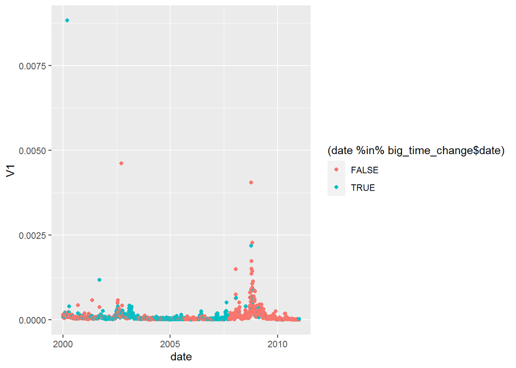

```r
# Where are the days with observations with >60 secs "time_change" concentrated?
daily_data <- data_ftse[ , sum(na.omit(log(price / data.table::shift(price)))^2), by=date] # unclean-RV
daily_data %>%
  ggplot() +
  geom_point(aes(x=date, y=V1, color=(date %in% big_time_change$date)))
```

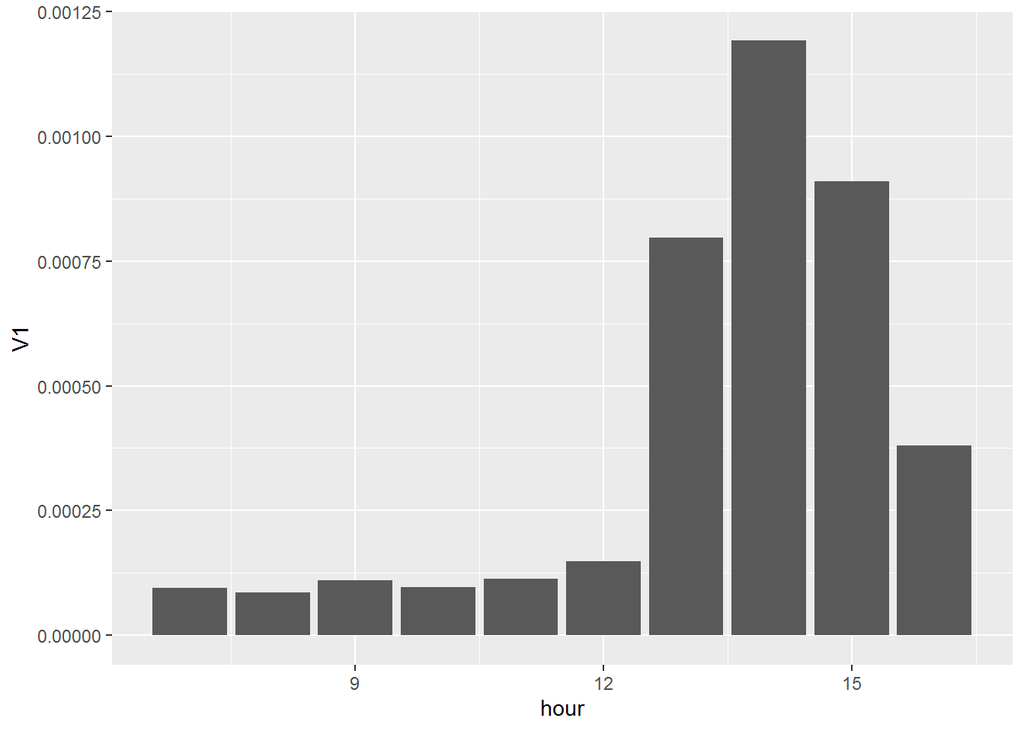

```r
# By hour of day
data_ftse[(!is_off_hours)][ , (sum(na.omit(time_change) > 60)
                              / length(time_change)), by=data.table::hour(time)] %>%
    select(hour = 'data.table', V1) %>%
    ggplot() +
    geom_bar(aes(x=hour, y=V1), stat="identity")
```

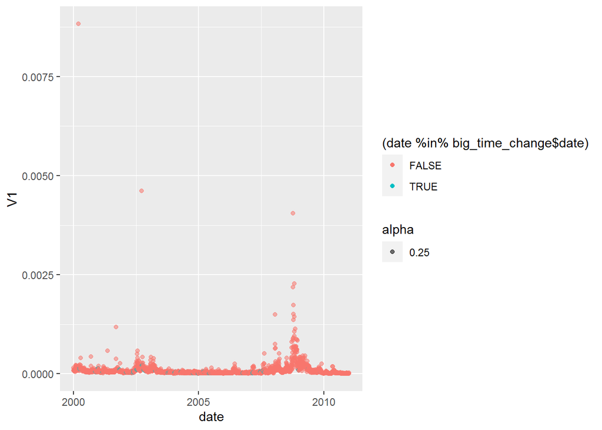

```r
# What if I increase the interval to >600 secs?
big_time_change <- big_time_change[time_change > 600]
daily_data %>%
  ggplot() +
  geom_point(aes(x=date, y=V1,
             color=(date %in% big_time_change$date),
             alpha=0.25))
```

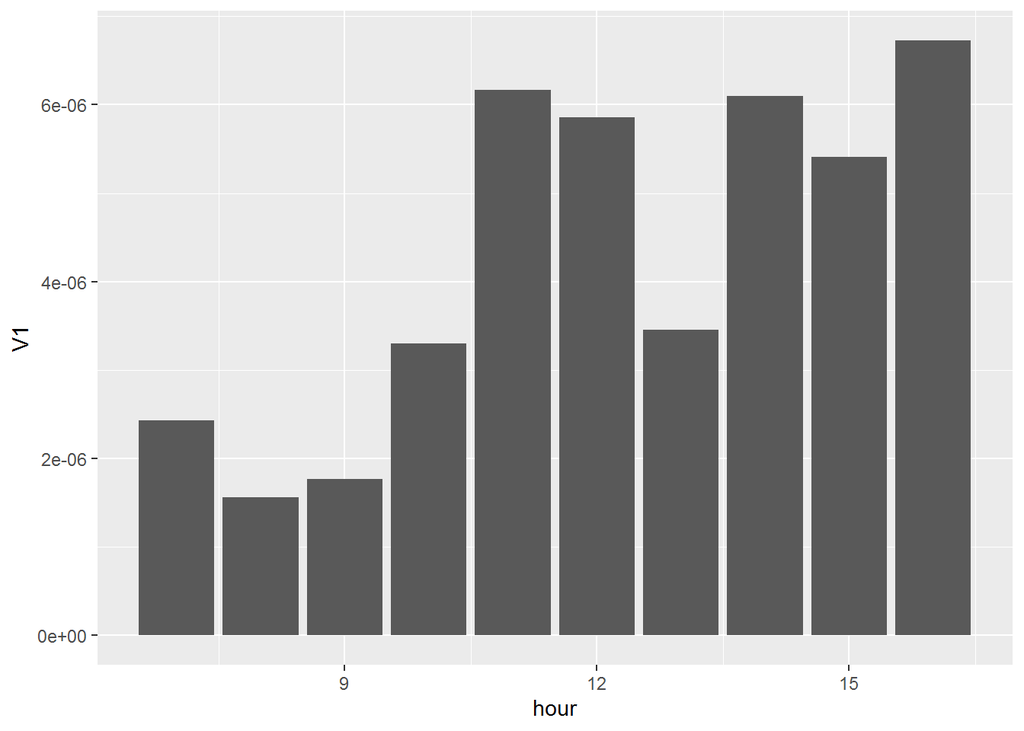

```r
# By hour of day
data_ftse[(!is_off_hours)][ , (sum(na.omit(time_change) > 600)
                              / length(time_change)), by=hour(time)] %>%
    ggplot() +
    geom_bar(aes(x=hour, y=V1), stat="identity")
```

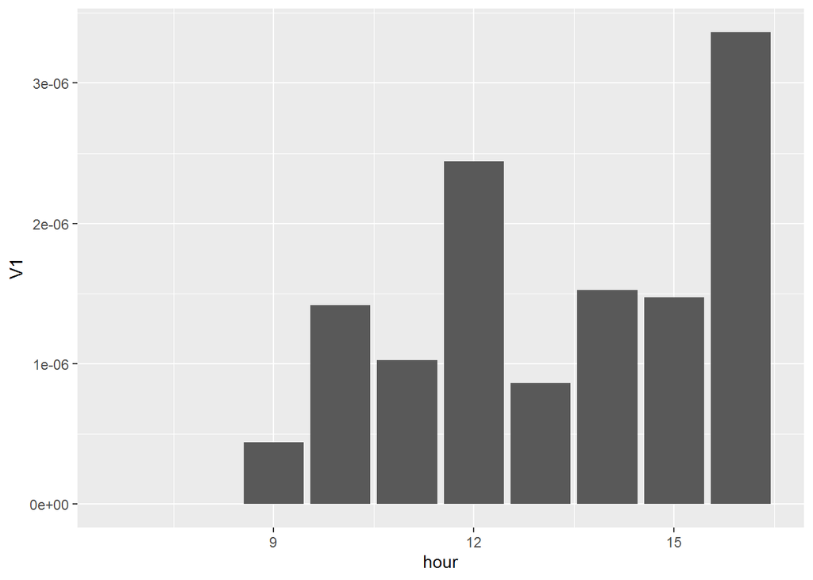

```r
# Interval to > 1800
data_ftse[(!is_off_hours)][ , (sum(na.omit(time_change) > 1800)
                              / length(time_change)), by=data.table::hour(time)] %>%
    select(hour = 'data.table', V1) %>%
    ggplot() +
    geom_bar(aes(x=hour, y=V1), stat="identity")
```

All returns that don’t happen when “is_day_change” is TRUE should be (1) positive and (2) relatively small. Because I’m going to use 1 minute returns, it would be good if all time_change were smaller than 60 seconds.

### Explanation for errors

- There are a lot of observations with a 0 time_change because there were duplicated prices. When all the prices except the last one are removed, these returns will remain *with the wrong number of time_change and returns*. The final clean file doesn’t have this issue because it does calculations after the removal of observations.

### Days with news

These are the only 3 days with news, and they’re also the days with the biggest anomalies in the time between observations. **None of them are going to be deleted.**

### Days without any news (ordered by the biggest time_change)

These are the days where I checked for an anomaly, but I didn’t find anything. Below 30 minutes there are way too many observations. Given that I didn’t find anything wrong with the other ones, I just inspected them visually (see graph above) and, again, didn’t find anything suspect.

#### More than one hour between observations

2004-01-27, 2004-01-27, 2005-01-31, 2005-06-13, 2007-02-26, 2002-01-30

#### Less than 1 hour and more than 30 minutes between observations

2009-11-10, 2000-11-21, 2007-08-30, 2007-07-18, 2002-11-20, 2002-10-21, 2007-08-29, 2005-02-01, 2001-03-05, 2005-03-29, 2000-11-23

### Days with too many anomalous observations

If the other anomalous observations are a mistake by the exchange, there isn’t much I can do about them.

This is either a problem on the side of the exchange, or a lack of trading that’s not generating the quotes. The observations cluster in times where the volatility is lower.

They are also more frequent in every period except the mornings, which isn’t very informative – the volume is bigger at the start and end of the day, not just at the start. I would expect to see a slight upward bias here – we are looking at observations after long periods without any of them – but nothing that would come close to explaining that pattern.

### Returns that are too large

```r
# Intraday returns that look suspicious
data_ftse[(!is_day_change) & (!is_unordered_time)
            & (!is_duplicated) & (!is_off_hours)
            & (returns != 0)][order(-abs(returns))] %>%
  head
```

| date | time | price | returns | time_change | is_duplicated | is_day_change | is_unordered_day | is_unordered_time | is_wrong_price | returns_per_time | is_weekend | is_bst_time | is_off_hours | is_holiday | in_rv_dates | in_rv_dates_alt | in_vftse_dates |
| --- | --- | --- | --- | --- | --- | --- | --- | --- | --- | --- | --- | --- | --- | --- | --- | --- | --- |
| 2000-03-13 | 16:22:45 | 6912.80 | 0.06843895 | 183 | FALSE | FALSE | FALSE | FALSE | FALSE | 0.005059153 | FALSE | FALSE | FALSE | FALSE | TRUE | TRUE | TRUE |
| 2000-03-13 | 16:22:48 | 6474.20 | -0.06361007 | 1 | FALSE | FALSE | FALSE | FALSE | FALSE | 0.063610067 | FALSE | FALSE | FALSE | FALSE | TRUE | TRUE | TRUE |
| 2008-10-10 | 07:05:47 | 3970.37 | -0.02955784 | 16 | FALSE | FALSE | FALSE | FALSE | FALSE | 0.007389461 | FALSE | TRUE | FALSE | FALSE | TRUE | TRUE | TRUE |
| 2008-10-10 | 07:05:31 | 4091.30 | -0.02233108 | 15 | FALSE | FALSE | FALSE | FALSE | FALSE | 0.005765861 | FALSE | TRUE | FALSE | FALSE | TRUE | TRUE | TRUE |
| 2002-09-20 | 09:19:51 | 3842.50 | -0.02206556 | 19 | FALSE | FALSE | FALSE | FALSE | FALSE | 0.005062187 | FALSE | TRUE | FALSE | FALSE | TRUE | TRUE | TRUE |
| 2008-10-24 | 07:00:32 | 3961.48 | -0.02109058 | 14 | FALSE | FALSE | FALSE | FALSE | FALSE | 0.005636695 | FALSE | TRUE | FALSE | FALSE | TRUE | TRUE | TRUE |

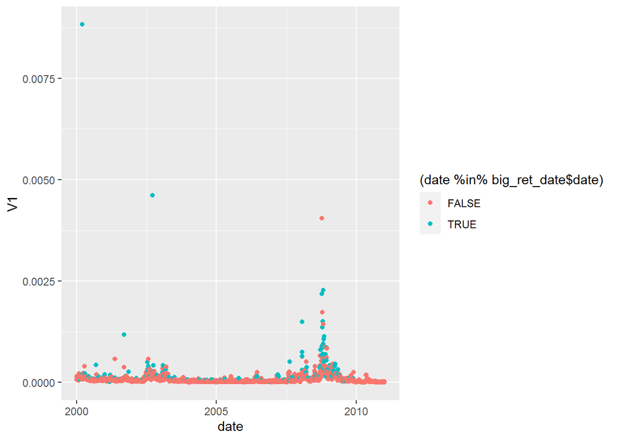

```r
# Realised volatility without data cleaned
daily_data <- data_ftse[ , sum(na.omit(log(price / data.table::shift(price)))^2), by=date]
big_ret_date <- data_ftse[ , sum(1*((na.omit(time_change) != 0)
                                   & (na.omit(returns) >= 0.005))),
                            by=date]
big_ret_date <- big_ret_date[(V1 > 0)]
# More volatility lead to more days with large returns
daily_data %>%
  ggplot(aes(x=date, y=V1, color=(date %in% big_ret_date$date))) +
  geom_point()
```

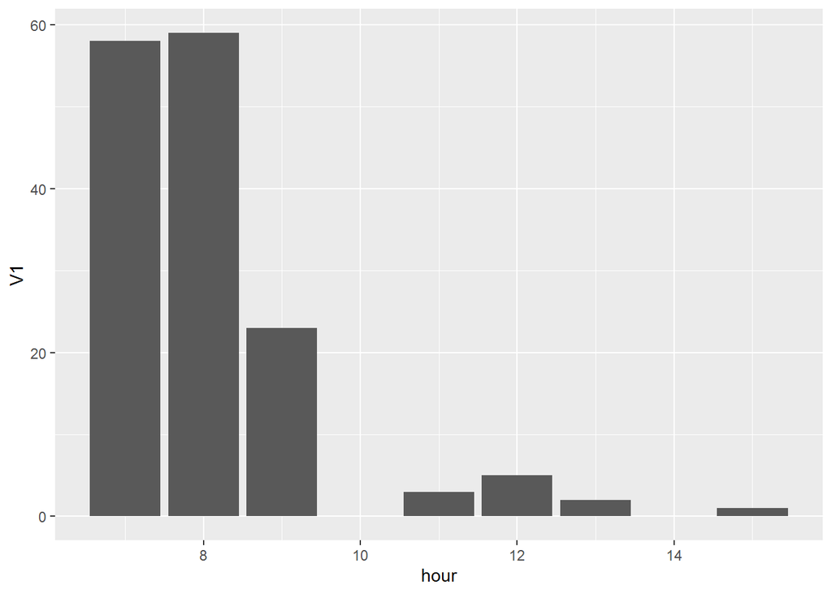

```r
# What big returns are closest to each other?
data_ftse[(!is_day_change) & (!is_unordered_time)
           & (!is_duplicated) & (!is_off_hours)
           & (returns >= 0.005) & (date %in% big_ret_date[(V1 > 1)]$date)
         ][ , length(returns), by=data.table::hour(na.omit(time))] %>%
  select(hour = 'data.table', V1) %>%
  ggplot(aes(x=hour, y=V1)) +
  geom_bar(stat='identity')
```

### Explanation

- 2000-03-13 at **16:22**: It’s going to be deleted. It has two 6% returns. One of them is positive and represents a ~3 minute return; the other happens 1 second after and it’s a negative return. There’s no news on that day. On Yahoo Finance the high of the day is 6568.70 and the close is 6466.90. The 3 minute return gives a price of 6912.80 (which is impossible, if Yahoo Finance’s data is correct) and the next return gives a price of 6474, which is near the 6466.90 close for the day.
- Every other big observation, with small exceptions, seems to cluster in periods of high volatility (2001/2002 and 2007/2008) and more towards the beginning of the day, where volatility also tends to be higher.

## Cleaning the data (first pass)

```r
# Confusing? Yes. But does it work? Yes. I could simplify it with `%in%`, but it takes a
# lot longer to run.
data_ftse <- data_ftse[(!is_duplicated)
                       & (!is_unordered_time)
                       & ((!is_off_hours) | ((is_off_hours)
                                              & ((date == '2000-04-05')
                                                  | (date == '2010-03-29')
                                                  | (date == '2010-03-30')
                                                  | (date == '2010-03-31'))))
                       & ((date != '2000-03-13') & (time != '16:22:45'))]
```

### Comparison to other RV data sets

```r
# (note: this comparison works because these the numbers are represented as strings)
sum(!(data_paper == data_paper_alt))  # Both alternative data sets are equal
```

```
## [1] 0
```

```r
# Dates in my data, but not in the RV data
missing_dates_rv <- data_ftse[(!in_rv_dates)]$date %>% unique %>% as.Date
```

```r
data_ftse[(!in_rv_dates)]$date %>% unique
```

```
##  [1] "2001-03-08" "2001-03-21" "2001-08-23" "2001-09-10" "2001-10-08"
##  [6] "2002-01-18" "2002-01-28" "2002-08-16" "2002-09-10" "2002-10-22"
## [11] "2003-01-17" "2003-01-21" "2003-04-10" "2003-10-16" "2004-01-12"
## [16] "2004-01-13" "2004-10-12" "2008-05-16" "2008-06-06" "2008-08-01"
## [21] "2008-08-07" "2008-08-13" "2009-02-27" "2010-03-19" "2010-05-07"
## [26] "2010-05-10"
```

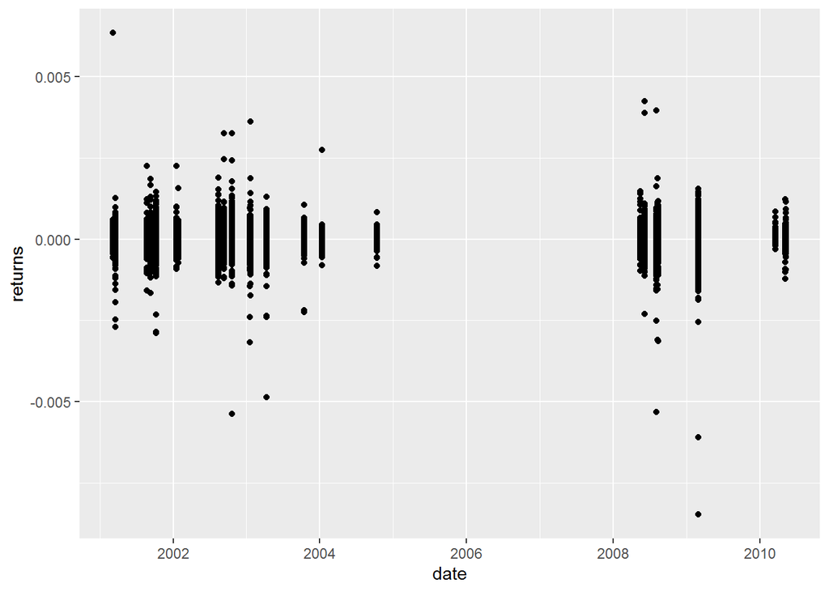

```r
data_ftse[(!in_rv_dates)] %>%
  ggplot(aes(y=returns, x=date)) +
  geom_point()
```

```r
# Dates in my data, but not in the vftse data
data_ftse[(!in_vftse_dates)]  # No dates
```

| date | time | price | returns | time_change | is_duplicated | is_day_change | is_unordered_day | is_unordered_time | is_wrong_price | returns_per_time | is_weekend | is_bst_time | is_off_hours | is_holiday | in_rv_dates | in_rv_dates_alt | in_vftse_dates |
| --- | --- | --- | --- | --- | --- | --- | --- | --- | --- | --- | --- | --- | --- | --- | --- | --- | --- |

```r
# Dates in the RV data, but not in my data
missing_dates_ftse1 <- data_paper[!(date %in% unique(data_ftse$date))]$date
print(missing_dates_ftse1)
```

```
##  [1] "2000-03-13" "2001-03-16" "2001-09-13" "2001-09-14" "2001-09-17"
##  [6] "2001-09-18" "2001-09-19" "2001-09-20" "2001-09-21" "2001-09-24"
## [11] "2001-09-25" "2001-09-26" "2001-09-27" "2001-09-28" "2001-10-01"
## [16] "2001-10-02" "2001-10-03" "2006-04-07"
```

```r
print(missing_dates_ftse1 %in% data_uk_holidays)  # Missing days aren't holidays
```

```
##  [1] FALSE FALSE FALSE FALSE FALSE FALSE FALSE FALSE FALSE FALSE FALSE FALSE
## [13] FALSE FALSE FALSE FALSE FALSE FALSE
```

```r
print(wday(missing_dates_ftse1))  # Seems pretty random
```

```
##  [1] 2 6 5 6 2 3 4 5 6 2 3 4 5 6 2 3 4 6
```

```r
# Dates in the vftse data, but not in my data
missing_dates_ftse2 <- data_vftse[!(date %in% unique(data_ftse$date))]$date
print(missing_dates_ftse2 %in% data_uk_holidays)  # Most of these are holidays
```

```
##   [1] FALSE  TRUE  TRUE  TRUE  TRUE  TRUE  TRUE  TRUE  TRUE FALSE  TRUE  TRUE
##  [13]  TRUE  TRUE  TRUE FALSE FALSE FALSE FALSE FALSE FALSE FALSE FALSE FALSE
##  [25] FALSE FALSE FALSE FALSE FALSE FALSE  TRUE  TRUE  TRUE  TRUE  TRUE  TRUE
##  [37]  TRUE  TRUE  TRUE  TRUE  TRUE  TRUE  TRUE  TRUE  TRUE  TRUE  TRUE  TRUE
##  [49]  TRUE  TRUE  TRUE  TRUE  TRUE  TRUE  TRUE  TRUE  TRUE  TRUE  TRUE  TRUE
##  [61]  TRUE  TRUE  TRUE  TRUE  TRUE  TRUE FALSE  TRUE  TRUE  TRUE  TRUE  TRUE
##  [73]  TRUE  TRUE  TRUE  TRUE  TRUE  TRUE  TRUE  TRUE  TRUE  TRUE  TRUE  TRUE
##  [85]  TRUE  TRUE  TRUE  TRUE  TRUE  TRUE  TRUE  TRUE  TRUE  TRUE  TRUE  TRUE
##  [97]  TRUE  TRUE  TRUE  TRUE  TRUE  TRUE  TRUE  TRUE  TRUE  TRUE
```

```r
print(wday(missing_dates_ftse2))  # Mostly on mondays, as expected because they're holidays
```

```
##   [1] 2 6 2 2 2 2 2 3 2 6 6 2 2 2 2 5 6 2 3 4 5 6 2 3 4 5 6 2 3 4 3 4 3 6 2 2 2
##  [38] 3 2 4 5 4 6 2 2 2 2 5 6 5 6 2 2 2 2 2 3 2 6 2 2 2 2 2 3 2 6 6 2 2 2 2 2 3
##  [75] 2 6 2 2 2 2 3 4 3 6 2 2 2 2 5 6 5 6 2 2 2 2 6 2 6 6 2 2 2 2 2 3
```

## Calculated RV with semi-cleaned data

```r
data_ftse[ , is_day_change := ((date - data.table::shift(date)) > 0)]
data_ftse[ , is_day_change := c(TRUE, is_day_change[2:length(is_day_change)])]
data_ftse[ , date_time := as.POSIXct(paste(date, time),
                                     format="%Y-%m-%d %H:%M:%S",
                                     tz="Europe/London")]
data_ftse[ , min_k_ceiling := ceiling_date(date_time, "1 min")]
last_5_min <- data_ftse[ , last(date_time), by=min_k_ceiling]$V1
data_ftse[ , min_k_stamp := ((date_time %in% last_5_min) | is_day_change)]
min_k <- data_ftse[(min_k_stamp)]
min_k <- min_k[ , c('date_time', 'price')]
min_k[ , returns := price/data.table::shift(price, 1) - 1]
```

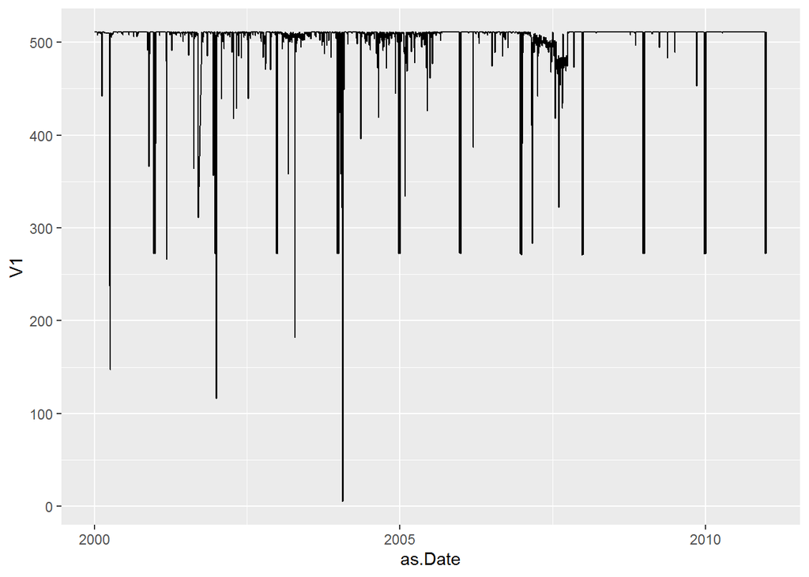

```r
# Days that are too short
# See if the typical day has the right number of returns (510 1-minute returns, or 511 prices)
n_obs <- min_k[ , length(price), by=as.Date(date_time)]
n_obs %>%
  ggplot(aes(x=as.Date, y=V1)) +
  geom_line()
```

```r
n_obs %>%
  arrange(V1) %>%
  head
```

|  | as.Date | V1 |
| --- | --- | --- |
| 1 | 2004-01-23 | 5 |
| 2 | 2001-12-31 | 116 |
| 3 | 2000-04-05 | 147 |
| 4 | 2003-04-14 | 182 |
| 5 | 2000-04-03 | 237 |
| 6 | 2001-03-08 | 266 |

I only found information about: - 2000-04-05: day with the technical problems - 2001-09-12: day after 9/11

Didn’t search extensively for all other days. The biggest anomaly is in 2004-01-23, and there’s no information about that. It seems perfectly normal to have days that are shorter by about 5-to-15 minutes (though they seem to happen mostly before 2005, especially in 2004). I searched more for information between 2004-01 and 2004-05 but couldn’t find anything. Once again, it’s a problem that’s common, and I don’t have a good way of knowing if there’s anything wrong with them.

## Clean data (second pass)

```r
exc_60_pct <- n_obs[!(V1 <= (511*0.6))]$as.Date
data_ftse <- data_ftse[(date %in% exc_60_pct)]
```

## Large returns

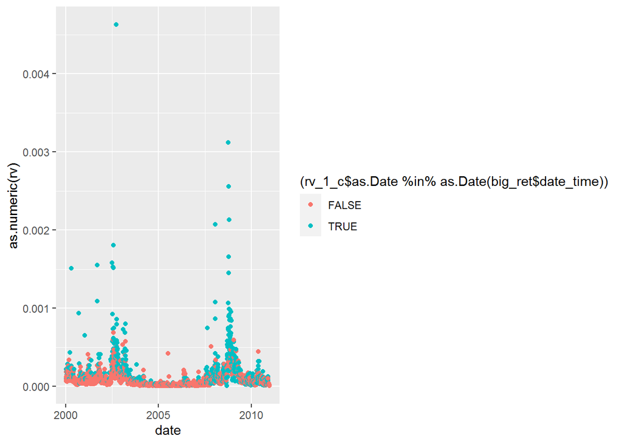

```r
min_1_ret <- data_ftse[(min_k_stamp)]
min_1_ret <- min_1_ret[ , c('date_time', 'price')]
min_1_ret[ , ret := (price / data.table::shift(price, 1) - 1)]
min_1_ret <- na.omit(min_1_ret)

big_ret <- min_1_ret[(abs(ret) > 0.005)]
big_ret_2 <- min_1_ret[(abs(ret) > 0.01)]
big_ret_3 <- min_1_ret[(abs(ret) > 0.02)]
rv_1 <- min_1_ret[ , sum(ret^2), by=as.Date(date_time)]

data_paper_c <- data_paper[(date %in% rv_1$as.Date)]
rv_1_c <- rv_1[(as.Date %in% data_paper_c$date)]

data_paper_c %>%
  ggplot(aes(x=date, y=as.numeric(rv),
         color=(rv_1_c$as.Date %in% as.Date(big_ret$date_time)))) +
  geom_point()
```

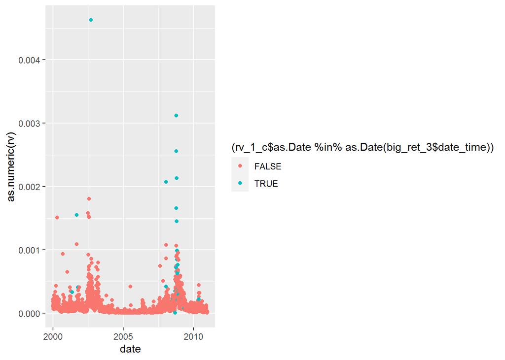

```r
data_paper_c %>% ggplot(aes(x=date, y=as.numeric(rv),
                    color=(rv_1_c$as.Date %in% as.Date(big_ret_3$date_time)))) +
  geom_point()
```

```r
big_ret %>%
  arrange(-abs(ret)) %>%
  head
```

|  | date_time | price | ret |
| --- | --- | --- | --- |
| 1 | 2008-10-10 07:05:47 | 3970.37 | -0.07100205 |
| 2 | 2008-10-13 07:05:46 | 4119.70 | 0.04063837 |
| 3 | 2008-12-08 08:05:46 | 4270.31 | 0.03619630 |
| 4 | 2008-10-24 07:00:46 | 3954.01 | -0.03273619 |
| 5 | 2008-10-27 08:00:46 | 3763.12 | -0.03096288 |
| 6 | 2008-12-12 08:00:46 | 4263.02 | -0.02863497 |

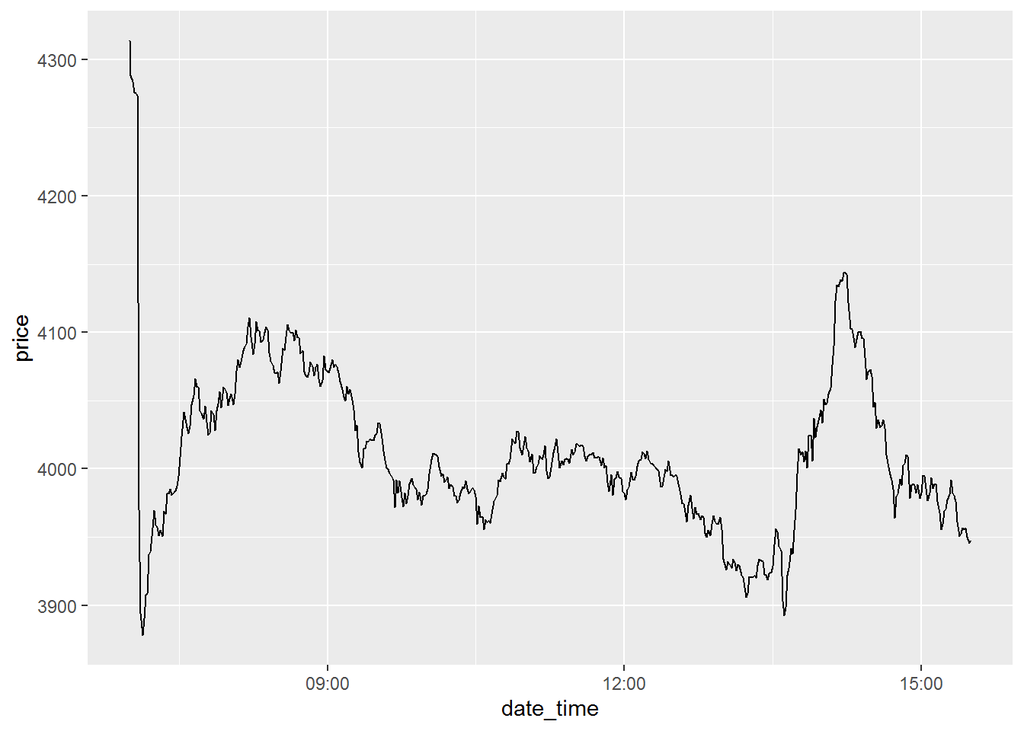

```r
min_1_ret[(as.Date(date_time) == as.Date('2008-10-10'))] %>%
  ggplot(aes(x=date_time, y=price)) +
  geom_line()
```

Again, it seems that most of the big returns are early in the day and they happen on the more volatile days. The only suspicious day is 2008-10-10, but that one was accompanied by news: https://www.telegraph.co.uk/finance/markets/ftse100/3171277/Financial-crisis-Worst-FTSE-falls-in-history.html, so it’s completely plausible that it happened, and the chart looks realistic.

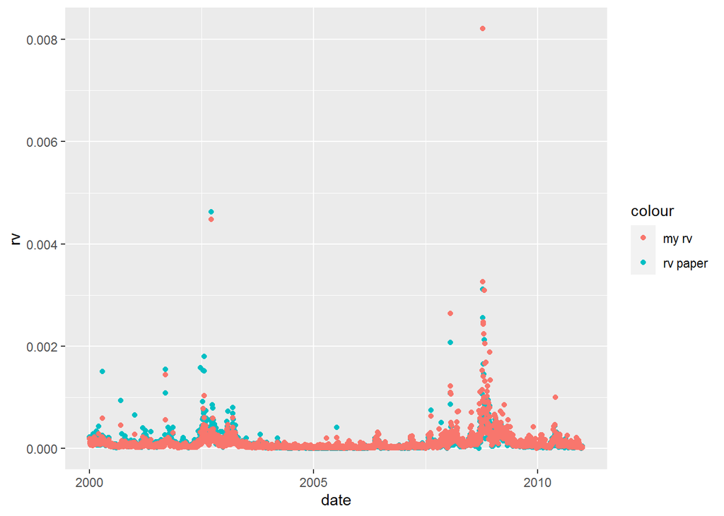

```r
# RV using only intraday returns
rv_5 <- min_k[ , sum(na.omit(log(price/data.table::shift(price)))^2), by=as.Date(date_time)]

compare_paper <- data_paper[(date %in% rv_5$as.Date)]
compare_rv <- rv_5[(as.Date %in% compare_paper$date)]

compare_paper[ , rv := (as.numeric(rv))]
compare_paper %>% ggplot(aes(x=date, y=rv)) +
  geom_point(aes(color='rv paper')) +
  geom_point(data=compare_rv, aes(x=as.Date, y=V1, color='my rv'))
```

```r
compare_rv[ , diff := V1 - compare_paper$rv]
print(head(compare_rv[order(-abs(diff))]))
```

```
##       as.Date          V1         diff
## 1: 2008-10-10 0.008209097  0.005654995
## 2: 2008-10-13 0.002473570  0.001756384
## 3: 2008-12-08 0.001889090  0.001595269
## 4: 2002-06-26 0.000316209 -0.001267337
## 5: 2008-10-29 0.001664943  0.001188726
## 6: 2008-10-27 0.002051431  0.001063651
```

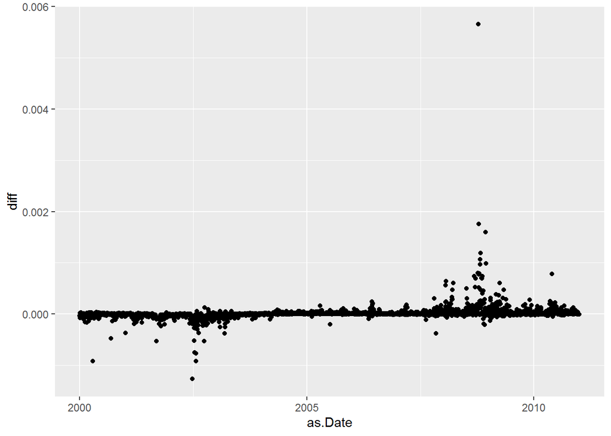

```r
compare_rv %>%
  ggplot(aes(x=as.Date, y=diff)) +
  geom_point()
```

There are some large differences, especially on ‘2008-10-10’ and ‘2008-10-13’. I suspect that’s it’s because the paper applies techniques to remove outliers. Consistent with that, most of the big differences in the data are arround 2008, and it’s my paper that seems to almost always overestimate volatility.

For the other data (DataStream’s FTSE 100 data set), I will just match the days because there were no other errors.